# Homework #4

Isaac Schennum (I don’t have a team)

2/23/2022

```r
library(ggplot2)
choco <- read.csv("https://ds202-at-isu.github.io/labs/data/choco.csv")
str(choco)
```

```
## 'data.frame':    1852 obs. of  9 variables:
##  $ Company             : chr  "A. Morin" "A. Morin" "A. Morin" "A. Morin" ...
##  $ Specific.Bean.Origin: chr  "Agua Grande" "Kpime" "Panama" "Madagascar" ...
##  $ REF                 : int  1876 1676 1011 1011 1011 1011 1015 1015 1015 1015 ...
##  $ Review.Date         : int  2016 2015 2013 2013 2013 2013 2013 2013 2013 2013 ...
##  $ Cocoa.Pct           : num  63 70 70 70 70 70 70 70 70 70 ...
##  $ Company.Location    : chr  "France" "France" "France" "France" ...
##  $ Rating              : num  3.75 2.75 2.75 3 3.25 3.75 2.75 3 3.25 4 ...
##  $ Bean.Type           : chr  "" "" "" "Criollo" ...
##  $ Broad.Bean.Origin   : chr  "Sao Tome" "Togo" "Panama" "Madagascar" ...
```

```r
head(choco, 10)
```

```
##     Company Specific.Bean.Origin  REF Review.Date Cocoa.Pct Company.Location
## 1  A. Morin          Agua Grande 1876        2016        63           France
## 2  A. Morin                Kpime 1676        2015        70           France
## 3  A. Morin               Panama 1011        2013        70           France
## 4  A. Morin           Madagascar 1011        2013        70           France
## 5  A. Morin               Brazil 1011        2013        70           France
## 6  A. Morin             Equateur 1011        2013        70           France
## 7  A. Morin             Colombie 1015        2013        70           France
## 8  A. Morin             Birmanie 1015        2013        70           France
## 9  A. Morin     Papua New Guinea 1015        2013        70           France
## 10 A. Morin                Chuao 1015        2013        70           France
##    Rating  Bean.Type Broad.Bean.Origin
## 1    3.75                     Sao Tome
## 2    2.75                         Togo
## 3    2.75                       Panama
## 4    3.00    Criollo        Madagascar
## 5    3.25                       Brazil
## 6    3.75                      Ecuador
## 7    2.75                     Colombia
## 8    3.00                        Burma
## 9    3.25             Papua New Guinea
## 10   4.00 Trinitario         Venezuela
```

```r
tail(choco, 10)
```

```
##      Company Specific.Bean.Origin REF Review.Date Cocoa.Pct Company.Location
## 1843  Zotter         Huiwani Coop 879        2012        75          Austria
## 1844  Zotter        El Ceibo Coop 879        2012        90          Austria
## 1845  Zotter        Santo Domingo 879        2012        70          Austria
## 1846  Zotter     Kongo, Highlands 883        2012        68          Austria
## 1847  Zotter        Indianer, Raw 883        2012        58          Austria
## 1848  Zotter                 Peru 647        2011        70          Austria
## 1849  Zotter                Congo 749        2011        65          Austria
## 1850  Zotter         Kerala State 749        2011        65          Austria
## 1851  Zotter         Kerala State 781        2011        62          Austria
## 1852  Zotter   Brazil, Mitzi Blue 486        2010        65          Austria
##      Rating           Bean.Type  Broad.Bean.Origin
## 1843   3.00 Criollo, Trinitario   Papua New Guinea
## 1844   3.25                                Bolivia
## 1845   3.75                     Dominican Republic
## 1846   3.25           Forastero              Congo
## 1847   3.50
## 1848   3.75                                   Peru
## 1849   3.00           Forastero              Congo
## 1850   3.50           Forastero              India
## 1851   3.25                                  India
## 1852   3.00                                 Brazil
```

```r
summary(choco)
```

```
##    Company          Specific.Bean.Origin      REF        Review.Date
##  Length:1852        Length:1852          Min.   :   5   Min.   :2006
##  Class :character   Class :character     1st Qu.: 600   1st Qu.:2010
##  Mode  :character   Mode  :character     Median :1099   Median :2013
##                                          Mean   :1065   Mean   :2012
##                                          3rd Qu.:1546   3rd Qu.:2015
##                                          Max.   :2008   Max.   :2017
##    Cocoa.Pct     Company.Location       Rating       Bean.Type
##  Min.   : 42.0   Length:1852        Min.   :1.000   Length:1852
##  1st Qu.: 70.0   Class :character   1st Qu.:3.000   Class :character
##  Median : 70.0   Mode  :character   Median :3.250   Mode  :character
##  Mean   : 71.7                      Mean   :3.191
##  3rd Qu.: 75.0                      3rd Qu.:3.500
##  Max.   :100.0                      Max.   :5.000
##  Broad.Bean.Origin
##  Length:1852
##  Class :character
##  Mode  :character
##
##
##
```

```r
dim(choco)
```

```
## [1] 1852    9
```

In this dataset, 1852 chocolate bars were rated. See summary(choco) and dim(choco) output.

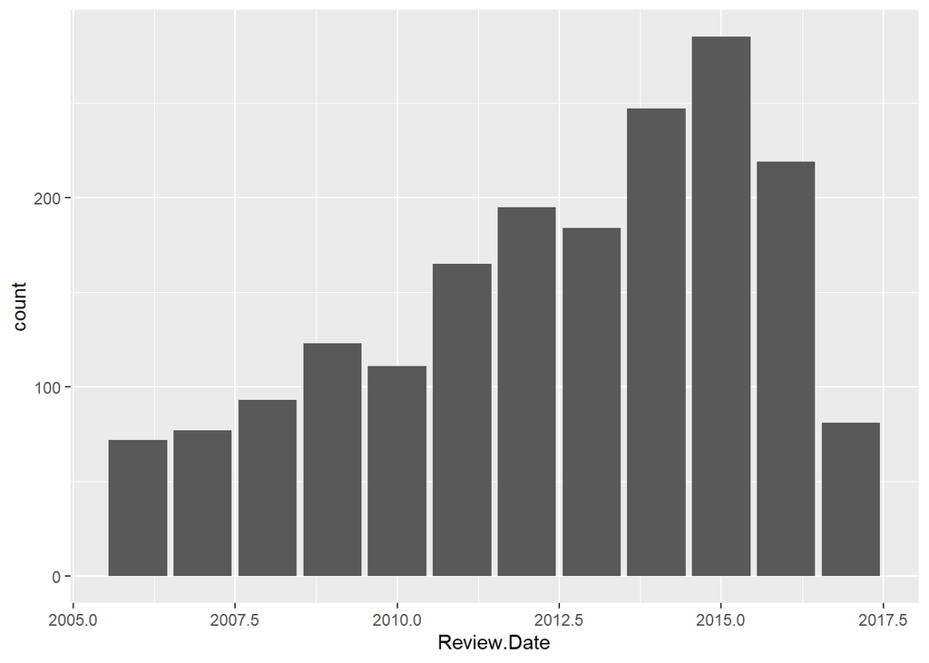

```r
ggplot(choco, aes(x = Review.Date)) + geom_bar()
```

The reviews were taken between 2006 and 2017. The distribution is unimodal, with the peak number of ratings occurring in 2015. The number of reviews increases somewhat steadily from 2006 until 2015, at which point the number of reviews heavily drops off.

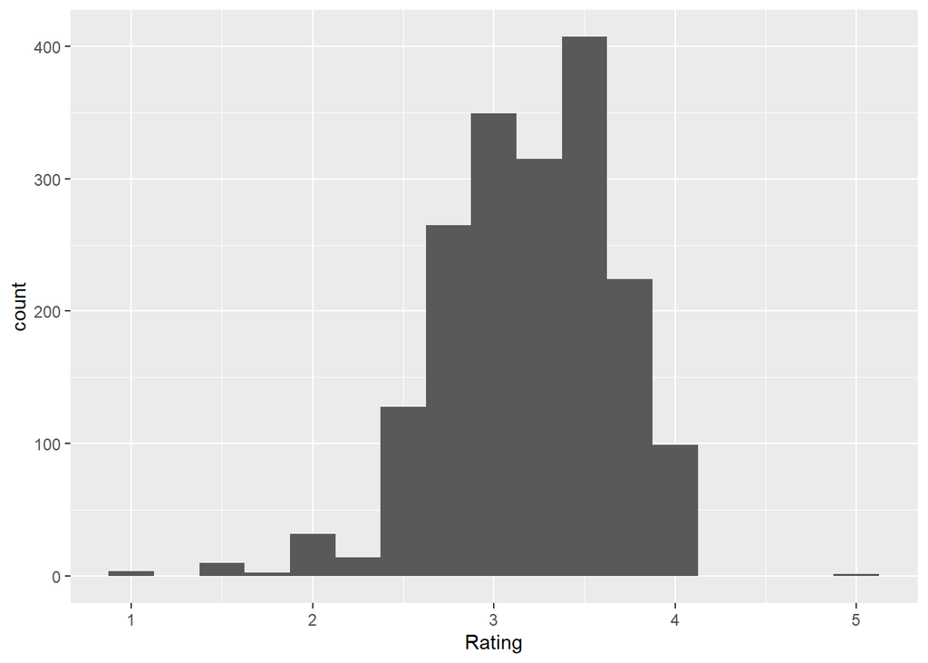

```r
ggplot(choco, aes(x = Rating)) + geom_histogram(bins = 17)
```

The ratings distribution is approximately normal, with a center around 3.25 and diminishing tails on both ends. The tail on the left is more pronounced, with a small but noticeable number of ratings between 1.5 and 2.25. There a few outlier ratings of 1 and 5.

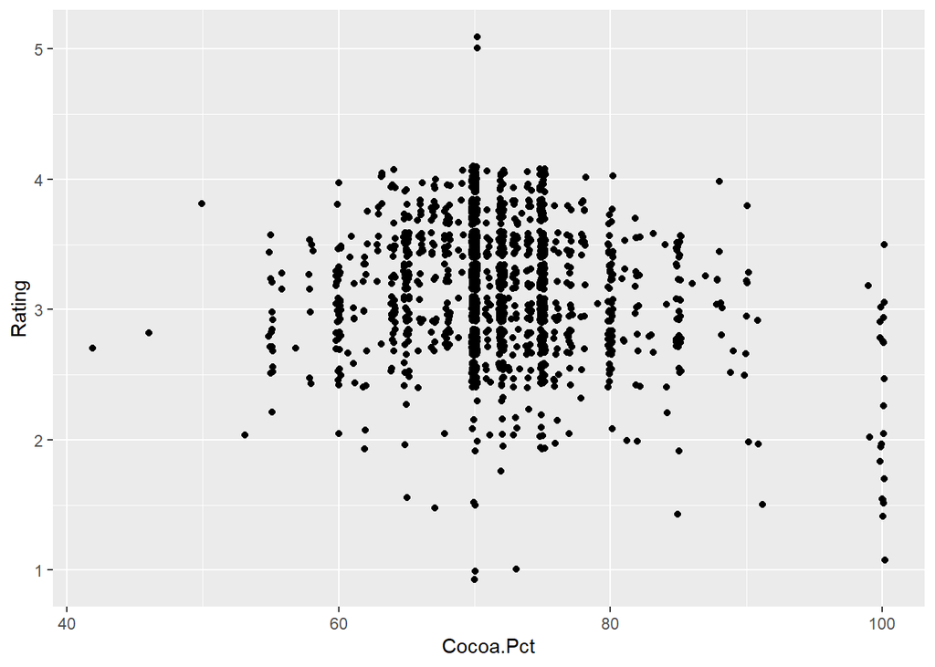

```r
ggplot(data = choco, aes(x = Cocoa.Pct, y = Rating)) + geom_jitter()
```

There doesn’t appear to be a relationship between ratings and cocoa percentages, given that there’s no apparent trend line on the scatterplot (the points seem to be scattered mostly randomly).

I installed R version 4.1.2 but it looks like it says I only have 0.4.12. I tried fixing it but I can’t figure it out. Unfortunately, I don’t have time to get it to work so I can’t answer question 3 on the problem set.

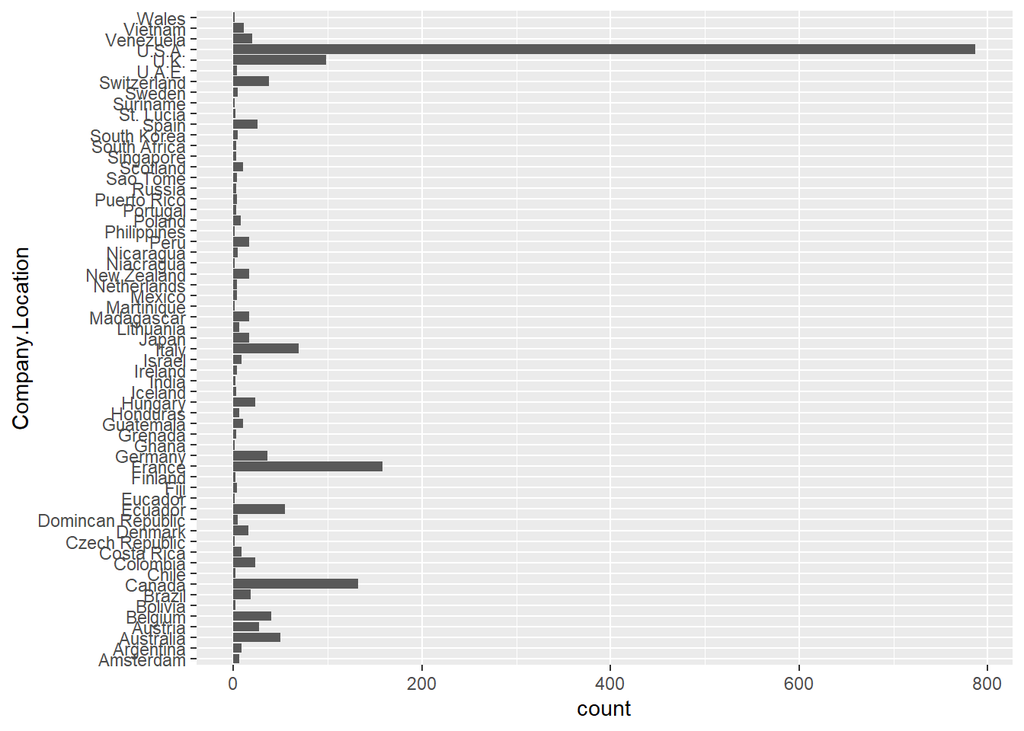

```r
ggplot(choco, aes(x = Company.Location)) + geom_bar() + coord_flip()
```

Conclusion: A very large portion of chocolate bars were manufactured by a company in the USA. This amount is around 5 times higher than the next highest country, France. In general, countries with a high number of chocolate bars being manufactured in them tend to be more well off countries. This is seen in that the UK, Italy, France, Canada, Switzerland, and Australia all have relatively high levels of chocolate manufacturing. The only notable exception is Ecuador, which has somewhat high production but is not as well off as the other countries listed.

The workflow of examining data was smooth, interesting, and enjoyable when I didn’t have random problems importing packages. It’s annoying when it feels like the problems I’m experiencing aren’t my fault (I feel like version 4.1.2 or R is being treated as version 0.4.12 for some reason), and trying to work out those problems in limited time was frustrating. Otherwise, it was fun to mess around with various graphs to get a better view of the data. I hope I can become more familiar with the features of ggplot2 in the future, since there are a few things I wanted to do that I didn’t know how to do (such as making the plot with all the countries taller so the text doesn’t overlap itself).